# Bellabeat Case Study - How Can a Wellness Technology Company Play It Smart?

March 2023

## **Introduction**

This is the Capstone Project for the Google Analytics Certificate, and I will walk you through my analysis process in order solve a Case Study, using R language.  
In this project, I will be taking the role of a Junior Data Analyst working on the marketing analytics team at a company.

Let’s meet our company!

## *Bellabeat*

[figure not shown]

*Bellabeat* is a successful small company, a high-tech manufacturer of health-focused products for women. Their products collect data on user activity, sleep, menstrual cycle, mindfulness habits and others, to help users take more informed and healthy decisions. Bellabeat has the potential to become a larger player in the global smart device market and believe that analyzing smart device fitness data could help unlock new growth opportunities for the company, positioning itself as a tech-driven wellness company for women.

## **1. Ask**

Bellabeat’s executive team asked the marketing analytics team to analyze smart device usage data in order to gain insight into how consumers use non-Bellabeat smart devices. Here are some of the questions they’re hope to be answered:

- What are some trends in smart device usage?
- How could these trends apply to Bellabeat customers?
- How could these trends help influence Bellabeat marketing strategy?

## **2. Prepare**

We’re encouraged to use a public data that explores smart device user’s daily habits. Here’s the dataset we’ll be using:

- [FitBit Fitness Tracker Data](https://www.kaggle.com/arashnic/fitbit) (A Public Domain dataset, made available trough [Mobius](https://www.kaggle.com/arashnic)).  
  This dataset contains 18 csv files containing data submitted by thirty users, who consented to share their personal tracker data. These files include information about daily steps, activity, sleeping minutes, heart-rate and others.

First, I will be taking a look over the csv files to understand how data is structured, what kind of metrics are being recorded and if there are any *“hidden surprises”*.

Let’s prepare our R environment:

```r
# install.packages("tidyverse")
# install.packages("janitor")


library(tidyverse)
library(janitor)
library(rmarkdown)
library(ggplot2)
library(ggpubr)
library(ggrepel)
```

Now it’s time to load our tables:

```r
# Calories burned daily
daily_calories <- read_csv("tables/dailyCalories_merged.csv")

# And let's see how this dataframe is organized
paged_table(head(daily_calories)) # paged_table - rmarkdown package (for a cleaner look). If the output dataframe is wider paged_table will divide it into pages that we can navigate through, clicking on the small arrow on the top corners
```

| Id | ActivityDay | Calories |
| --- | --- | --- |
| 1503960366 | 4/12/2016 | 1985 |
| 1503960366 | 4/13/2016 | 1797 |
| 1503960366 | 4/14/2016 | 1776 |
| 1503960366 | 4/15/2016 | 1745 |
| 1503960366 | 4/16/2016 | 1863 |
| 1503960366 | 4/17/2016 | 1728 |

```r
# Here I'm checking for unique user IDs.
n_distinct(daily_calories$Id)
```

```
## [1] 33
```

Out of the gate, I can see that we have 33 unique ID’s, which correspond to the number of subjects being studied, over the 31 day period. I can also see that the ActivityDay column is type character, not date. During the next phase I will address this issue. Also, as Bellabeat is a worldwide company (and for the sake of practicing) I’ll also standardize the date from month/day/year format to year/month/day.  
These same steps were taken for each of the tables given.

After going through the results, some dataframes have only 8 unique IDs, others present columns to which I can’t find clarification on what they are measuring. So, I will now follow with the tables I believe provide good quality data, in order to help answer Bellabeat’s business questions.

```r
# Total steps takes daily
daily_steps <- read_csv("tables/dailySteps_merged.csv")
# Daily activity intensity
daily_intensities <- read_csv("tables/dailyIntensities_merged.csv")
# Minutes of sleep per day
daily_sleep <- read_csv("tables/sleepDay_merged.csv")
# Steps taken hourly
hourly_steps <- read_csv("tables/hourlySteps_merged.csv")
# Calories burned hourly
hourly_calories <- read_csv("tables/hourlyCalories_merged.csv")
# Hourly activity intensity
hourly_intensities <- read_csv("tables/hourlyIntensities_merged.csv")
```

```r
n_distinct(daily_steps$Id)
```

```
## [1] 33
```

```r
n_distinct(daily_intensities$Id)
```

```
## [1] 33
```

```r
n_distinct(daily_sleep$Id)
```

```
## [1] 24
```

```r
n_distinct(hourly_steps$Id)
```

```
## [1] 33
```

```r
n_distinct(hourly_calories$Id)
```

```
## [1] 33
```

```r
n_distinct(hourly_intensities$Id)
```

```
## [1] 33
```

Even though daily_sleep only provides data for 24 unique users, it can still be helpful for our study.

## **3. Process**

In this phase, I will be going through the previously defined dataframes and clean them, following these steps:

1. Check for duplicates and blanks;
2. Change the columns names to “snake_case_format”;
3. Clean and standardize date and date/time columns;
4. Check for any abnormal observations in our dataframes;
5. Merge dataframes into a new clean dataframe;

### 3a. Check for duplicates and blanks

```r
sum(duplicated(daily_calories))
```

```
## [1] 0
```

```r
sum(duplicated(daily_steps))
```

```
## [1] 0
```

```r
sum(duplicated(daily_intensities))
```

```
## [1] 0
```

```r
sum(duplicated(hourly_steps))
```

```
## [1] 0
```

```r
sum(duplicated(hourly_calories))
```

```
## [1] 0
```

```r
sum(duplicated(hourly_intensities))
```

```
## [1] 0
```

- All previous dataframes returned 0 duplicates.

```r
sum(duplicated(daily_sleep))
```

```
## [1] 3
```

- daily_sleep is the only dataframe to return duplicates, with 3. Time to remove empty columns and rows, duplicates and blanks (if any).

```r
daily_calories <- daily_calories %>%
  remove_empty(which = c("rows", "cols")) %>% ## remove_empty - janitor package
  distinct() %>%
  drop_na()

daily_steps <- daily_steps %>%
  remove_empty(which = c("rows", "cols")) %>%
  distinct() %>%
  drop_na()

daily_intensities <- daily_intensities %>%
  remove_empty(which = c("rows", "cols")) %>%
  distinct() %>%
  drop_na()

hourly_steps <- hourly_steps %>%
  remove_empty(which = c("rows", "cols")) %>%
  distinct() %>%
  drop_na()

hourly_calories <- hourly_calories %>%
  remove_empty(which = c("rows", "cols")) %>%
  distinct() %>%
  drop_na()

hourly_intensities <- hourly_intensities %>%
  remove_empty(which = c("rows", "cols")) %>%
  distinct() %>%
  drop_na()

daily_sleep <- daily_sleep %>%
  remove_empty(which = c("rows", "cols")) %>%
  distinct() %>%
  drop_na()
```

### 3b. Change the columns names to “snake_case_format”

```r
daily_calories <- clean_names(daily_calories)
daily_steps <- clean_names(daily_steps)
daily_intensities <- clean_names(daily_intensities)
hourly_steps <- clean_names(hourly_steps)
hourly_calories <- clean_names(hourly_calories)
hourly_intensities <- clean_names(hourly_intensities)
daily_sleep <- clean_names(daily_sleep)

# Preview the output of one of the dataframes
paged_table(head(daily_sleep))
```

| id | sleep_day | total_sleep_records | total_minutes_asleep | total_time_in_bed |
| --- | --- | --- | --- | --- |
| 1503960366 | 4/12/2016 12:00:00 AM | 1 | 327 | 346 |
| 1503960366 | 4/13/2016 12:00:00 AM | 2 | 384 | 407 |
| 1503960366 | 4/15/2016 12:00:00 AM | 1 | 412 | 442 |
| 1503960366 | 4/16/2016 12:00:00 AM | 2 | 340 | 367 |
| 1503960366 | 4/17/2016 12:00:00 AM | 1 | 700 | 712 |
| 1503960366 | 4/19/2016 12:00:00 AM | 1 | 304 | 320 |

### 3c. Clean and standardize date and date/time columns

Let me break this down into smaller steps:

- All date related columns will be formatted from character type “mm/dd/yyyy” to date type “yyyy/mm/dd”.  
  In some dataframes I can see date/time observations. These will also need to be formatted into datetime “yyyy/mm/dd hh:mm”, dropping the “AM/PM” and adopting the 24h format.
- For a clearer analysis, the date/datetime columns will be renamed.

```r
daily_calories <- daily_calories %>%
  rename(date = activity_day) %>%
  mutate(date = mdy(date))

daily_steps <- daily_steps %>%
  rename(date = activity_day) %>%
  mutate(date = mdy(date))

daily_intensities <- daily_intensities %>%
  rename(date = activity_day, lightly_active_distance = light_active_distance) %>% # to follow logic
  mutate(date = mdy(date))

hourly_steps <- hourly_steps %>%
  rename(date_time = activity_hour) %>%
  mutate(date_time = mdy_hms(date_time))

hourly_calories <- hourly_calories %>%
  rename(date_time = activity_hour) %>%
  mutate(date_time = mdy_hms(date_time))

hourly_intensities <- hourly_intensities %>%
  rename(date_time = activity_hour) %>%
  mutate(date_time = mdy_hms(date_time))

daily_sleep <- daily_sleep %>% # date time is always listed as 12AM, so we don't actually need it.
  rename(date = sleep_day) %>%
  mutate(date = as.Date(date, format("%m/%d/%Y %H:%M:%S %p")))
```

### 3d. Check for any abnormal observations in our dataframes

```r
daily_calories %>%
  summarize(min = min(calories), max = max(calories))
```

```
## # A tibble: 1 × 2
##     min   max
##   <dbl> <dbl>
## 1     0  4900
```

There are rows where no calorie burn was registered. This is odd, considering we are always burning calories, even in complete rest. Calories burned can vary a lot due to a large variety of factors, so I’ll just remove 0 values observations.

```r
daily_steps %>%
  summarize(min = min(step_total), max = max(step_total))
```

```
## # A tibble: 1 × 2
##     min   max
##   <dbl> <dbl>
## 1     0 36019
```

We found here a lot of observations with 0 steps registered. That’s very unlikely, should explore further.

```r
daily_intensities %>%
  summarize(min = min(sedentary_minutes), max = max(sedentary_minutes))
```

```
## # A tibble: 1 × 2
##     min   max
##   <dbl> <dbl>
## 1     0  1440
```

Another odd finding. We have some observations where users had 0 sedentary minutes, which is very unlikely because sleeping is considered sedentary activity. On the other hand, we can also find 1440 minutes of sedentary activity. That would mean that users would be sedentary for 24H. Again, it’s unlikely. Even if a user has a desk job / office job, 24H at full rest seems exagerated.  
We can start speculating these values might indicate that the tracker device wasn’t being used at the time of these measurements. Maybe the device ran out of battery, the user forgot to put it on, or simply just charging for a period of time.

#### For the next steps we will assume that:

- A user will not have sedentary time of 24h nor 0h;
- Sedentary time will not be over 23h (even with a 10h desk job and 10h sleep time);
- Sedentary time will not be under 3h (due to unlikeliness);
- Step total will be over 100 steps. Anything below that will be excluded;
- Calories are always being burnt. We exclude values of 0.

### 3e. Merge dataframes into a new clean dataframe

First, the dataframe with the daily activity observations

```r
# Creating a list with the dataframes we want to merge
list_daily_activity <- list(daily_steps, daily_intensities, daily_calories)

# Merging into one dataframe
daily_activity_merged <- Reduce(function(x, y) merge(x, y, all = TRUE), list_daily_activity)

# Subset to keep only the values we want, removing the outliers
daily_activity_clean <- daily_activity_merged %>%
  subset(step_total > 100) %>% # removing the outliers
  subset(sedentary_minutes < 1380 & sedentary_minutes >= 180) %>%
  subset(calories > 0)

paged_table(head(daily_activity_clean)) # Wider dataframe, we can navigate through the pages by clicking the top corner arrow
```

|  | id | date | step_total | sedentary_minutes | lightly_active_minutes | fairly_active_minutes | very_active_minutes | sedentary_active_distance | lightly_active_distance | moderately_active_distance | very_active_distance | calories |
| --- | --- | --- | --- | --- | --- | --- | --- | --- | --- | --- | --- | --- |
| 1 | 1503960366 | 2016-04-12 | 13162 | 728 | 328 | 13 | 25 | 0 | 6.06 | 0.55 | 1.88 | 1985 |
| 2 | 1503960366 | 2016-04-13 | 10735 | 776 | 217 | 19 | 21 | 0 | 4.71 | 0.69 | 1.57 | 1797 |
| 3 | 1503960366 | 2016-04-14 | 10460 | 1218 | 181 | 11 | 30 | 0 | 3.91 | 0.40 | 2.44 | 1776 |
| 4 | 1503960366 | 2016-04-15 | 9762 | 726 | 209 | 34 | 29 | 0 | 2.83 | 1.26 | 2.14 | 1745 |
| 5 | 1503960366 | 2016-04-16 | 12669 | 773 | 221 | 10 | 36 | 0 | 5.04 | 0.41 | 2.71 | 1863 |
| 6 | 1503960366 | 2016-04-17 | 9705 | 539 | 164 | 20 | 38 | 0 | 2.51 | 0.78 | 3.19 | 1728 |

Now, the hourly activity dataframe is merged

```r
list_hourly_activity <- list(hourly_steps, hourly_intensities, hourly_calories)

hourly_activity_merged <- Reduce(function(x, y) merge(x, y, all = TRUE), list_hourly_activity)

# Subset to keep only the values we want
hourly_activity_clean <- hourly_activity_merged %>%
  subset(step_total > 100) # it's the only column failing our above assumptions

paged_table(head(hourly_activity_clean))
```

|  | id | date_time | step_total | total_intensity | average_intensity | calories |
| --- | --- | --- | --- | --- | --- | --- |
| 1 | 1503960366 | 2016-04-12 00:00:00 | 373 | 20 | 0.333333 | 81 |
| 2 | 1503960366 | 2016-04-12 01:00:00 | 160 | 8 | 0.133333 | 61 |
| 3 | 1503960366 | 2016-04-12 02:00:00 | 151 | 7 | 0.116667 | 59 |
| 9 | 1503960366 | 2016-04-12 08:00:00 | 250 | 13 | 0.216667 | 68 |
| 10 | 1503960366 | 2016-04-12 09:00:00 | 1864 | 30 | 0.500000 | 141 |
| 11 | 1503960366 | 2016-04-12 10:00:00 | 676 | 29 | 0.483333 | 99 |

We end up with 3 dataframes:

- daily_activity_clean
- hourly_activity_clean
- daily_sleep

Final check for outliers

```r
# daily_activity_clean
# hourly_activity_clean
# daily_sleep

summary(daily_activity_clean$step_total)
```

```
##    Min. 1st Qu.  Median    Mean 3rd Qu.    Max.
##     152    5206    8240    8627   11196   36019
```

```r
summary(daily_activity_clean$sedentary_minutes)
```

```
##    Min. 1st Qu.  Median    Mean 3rd Qu.    Max.
##   218.0   720.0   986.0   941.5  1172.0  1377.0
```

```r
summary(daily_activity_clean$calories)
```

```
##    Min. 1st Qu.  Median    Mean 3rd Qu.    Max.
##     741    1878    2241    2389    2846    4900
```

```r
summary(hourly_activity_clean$step_total)
```

```
##    Min. 1st Qu.  Median    Mean 3rd Qu.    Max.
##   101.0   231.0   423.0   719.5   812.0 10554.0
```

```r
summary(hourly_activity_clean$calories)
```

```
##    Min. 1st Qu.  Median    Mean 3rd Qu.    Max.
##    48.0    89.0   114.0   131.9   148.0   948.0
```

```r
summary(daily_sleep$total_minutes_asleep)
```

```
##    Min. 1st Qu.  Median    Mean 3rd Qu.    Max.
##    58.0   361.0   432.5   419.2   490.0   796.0
```

Nothing unsual was found. Time to jump to the next phase!

## **4. Analyze** + **5. Share**

It’s time to further analyze our final dataframes and I’m hoping to find trends and correlations. Then, I’ll create a few visuals to help Stakeholders better understand any findings that may appear.  
First, I want to create a theme for the plots that I’ll be using regularly.

```r
# Defining plots theme
theme <- theme(plot.background = element_rect(fill = "mistyrose"),
               panel.border = element_rect(fill = "transparent", color = "salmon2", linewidth = 2),
               panel.background = element_rect(fill = "mistyrose"),
               panel.grid = element_line(color="snow"),
               plot.title = element_text(size = 14),
               axis.title = element_text(size = 12),
               axis.text = element_text(size = 9))
```

Then, the plots.

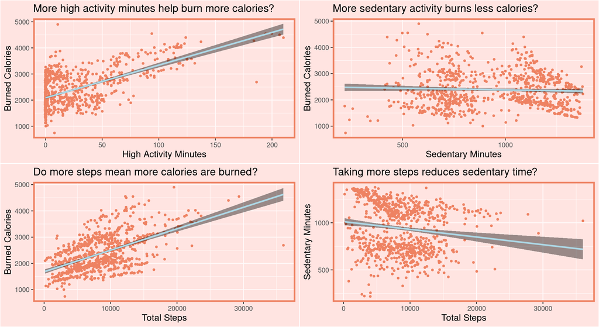

```r
# Scatter plot: very_active_minutes vs calories
active_min_vs_calories_plot <- ggplot(daily_activity_clean, aes(x = very_active_minutes, y = calories)) +
  geom_jitter(size = 1, color = "salmon2") +
  geom_smooth(method = "lm", color = "lightblue", fill = "black") +
  labs(title = "More high activity minutes help burn more calories?", x = "High Activity Minutes", y = "Burned Calories") +
  theme

# Scatter plot: sedentary_minutes vs calories
sedentary_min_vs_calories_plot <- ggplot(daily_activity_clean, aes(x = sedentary_minutes, y = calories)) +
  geom_jitter(size = 1, color = "salmon2") +
  geom_smooth(method = "lm", color = 'lightblue', fill = "black") +
  labs(title = "More sedentary activity burns less calories?", x = "Sedentary Minutes", y = "Burned Calories") +
  theme # check here average calories burnt studies when in total rest to compare to sedentarism

# Scatter Plot: step_total vs calories
steps_vs_calories_plot <- ggplot(daily_activity_clean, aes(x = step_total, y = calories)) +
  geom_jitter(size = 1, color ="salmon2" ) +
  geom_smooth(method = "lm", color = "lightblue", fill = "black") +
  labs(title = "Do more steps mean more calories are burned? ", x = "Total Steps", y = "Burned Calories") +
  theme

# Scatter plot: total_steps vs sedentary minutes
steps_vs_sedentary_min_plot <- ggplot(daily_activity_clean, aes(x = step_total, y = sedentary_minutes)) +
  geom_jitter(size = 1, color = "salmon2") +
  geom_smooth(method = "lm", color = "lightblue", fill = "black") +
  labs(title = "Taking more steps reduces sedentary time?", x = "Total Steps", y = "Sedentary Minutes") +
  theme

# Combining all Scatter Plots into one visualization
ggarrange(active_min_vs_calories_plot, sedentary_min_vs_calories_plot, steps_vs_calories_plot, steps_vs_sedentary_min_plot)
```

- I can see a positive correlation between high intensity activity minutes, the total steps taken and the number of calories burned. This makes sense because the more active we are, the more calories we are going to burn.
- There is no apparent correlation between the total of sedentary activity and the amount of calories burned. Logically, I can imagine the more sedentary one is, the less calories one’s body will consume. But, one could have a high intensity peak at some point of the day, that could help boost the amount of calories burned.
- The last scatter plot can help understand that even if the total steps taken in a day increases, that doesn’t necessarily mean the sedentary time will decrease. There’s a small correlation there, but not very strong. Connecting to the previous observation, maybe it strengthens the hypothesis that a high intensity peak (more steps in a short period of time) could reduce a bit of the sedentary time, without a drastic drop. Naturally, sleep time also comes in play here, which is accounted for as sedentary time.

Let’s find out at what time of the day users are usually more active.

```r
# New dataframe
intensities_df <- hourly_activity_clean %>%
  group_by(time = format(date_time, "%H:%M")) %>%
  summarize(mean_total_intensity = mean(total_intensity))

# Finding the mean
summary(intensities_df$mean_total_intensity) ## To check the mean intensity daily
```

```
##    Min. 1st Qu.  Median    Mean 3rd Qu.    Max.
##   11.85   20.69   24.95   23.28   27.56   30.49
```

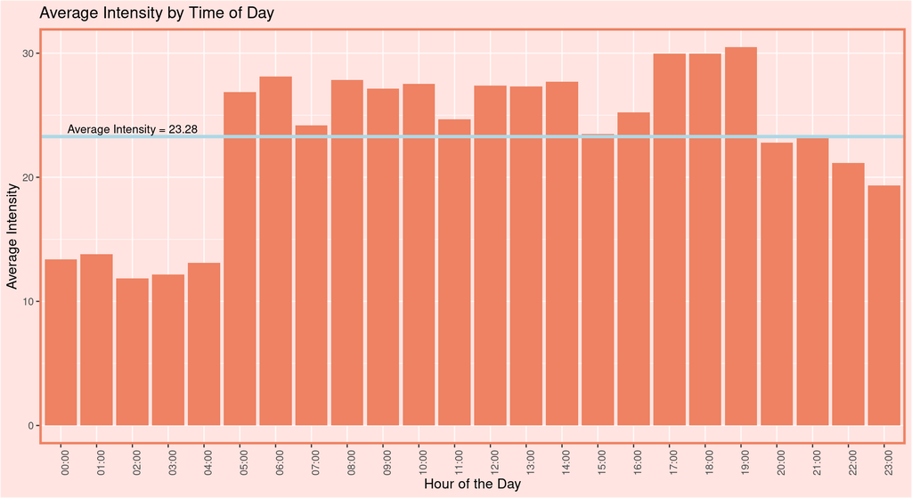

```r
# Histogram Plot: Hourly Intensities
histogram_intensities <- ggplot(intensities_df, aes(x = time, y = mean_total_intensity)) +
  geom_histogram(stat = 'identity', fill = "salmon2") +
  labs(title = "Average Intensity by Time of Day", x = "Hour of the Day", y = "Average Intensity") +
  geom_hline(yintercept = 23.28, color = "lightblue", size = 1.4) + # Average intensity
  annotate("text", x = 3, y = 23.9, size = 3.5, label = "Average Intensity = 23.28") +
  theme +
  theme(axis.text.x = element_text(angle = 90))

histogram_intensities
```

- This plot can help understand that users are more active between 5:00 and 19:00. Their activity levels significantly decreases between 20:00 and 4:00, which is explained by the conventional sleep schedules.
- The peak of intensity comes between 17:00 and 19:00. Maybe this is the preferred time for users to engage in some sports activity - going to the gym or for a run outside - after work-hours.  
  There’s a smaller peak at around 5:00 and 6:00. Could this mean that some of our sample users enjoy their exercise in the early morning?

I’m looking to understand now on what days of the week users are more active - how many steps do they take on average? Are they walking the recommended amount of steps per day?  
And are they sleeping the recommended hours?  
Let’s dive!

```r
# Merging into a new dataframe to better understand sleeping patterns
daily_activity_sleep_clean <- merge(daily_activity_clean, daily_sleep, by = c("id", "date"))
```

```r
# Analyze total steps and sleeping minutes per weekday

daily_activity_sleep_clean$day <- weekdays(as.Date(daily_activity_sleep_clean$date)) # Finding the weekday for the date

# Summarize the average total steps per weekday
weekday_avg_steps <- daily_activity_sleep_clean %>%
  group_by(day) %>%
  summarize(avg_steps_daily = mean(step_total))

weekday_avg_steps$day <- ordered(weekday_avg_steps$day, # Sorting from Monday to Sunday
                                 levels = c("Monday", "Tuesday", "Wednesday", "Thursday", "Friday", "Saturday", "Sunday"))

# Summarize the average minutes of sleep per weekday
weekday_avg_sleep <- daily_activity_sleep_clean %>%
  group_by(day) %>%
  summarize(avg_sleep_daily = mean(total_minutes_asleep))

weekday_avg_sleep$day <- ordered(weekday_avg_sleep$day,
                                 levels = c("Monday", "Tuesday", "Wednesday", "Thursday", "Friday", "Saturday", "Sunday"))
```

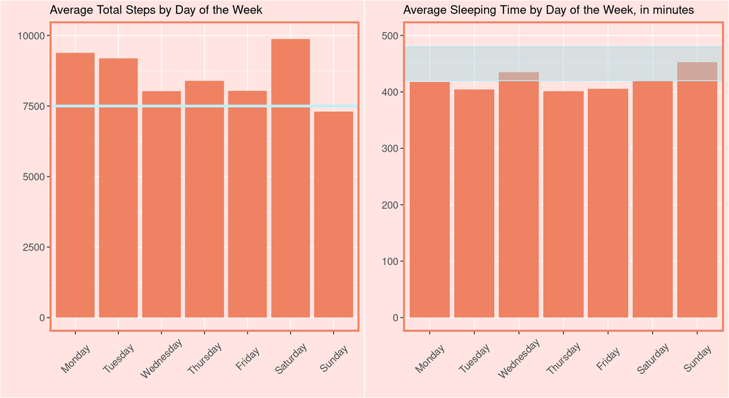

```r
# Bar plot representing the average total steps by weekday
steps_weekday_barplot <- ggplot(weekday_avg_steps, aes(x = day, y = avg_steps_daily)) +
  geom_bar(stat = "identity", fill = "salmon2") +
  ylim(0, 10000) +
  geom_hline(yintercept = 7500, color = "lightblue1", size = 1.4) +
  labs(title = "Average Total Steps by Day of the Week", x = "", y = "") +
  theme +
  theme(plot.title = element_text(size = 13), axis.text = element_text(size = 11),
        axis.title = element_text(size = 11), axis.text.x = element_text(angle = 45, vjust = 0.5, hjust = 0.5))

# Bar plot representing the average slept time by weekday
sleep_weekday_barplot <- ggplot(weekday_avg_sleep, aes(x = day, y = avg_sleep_daily)) +
  geom_bar(stat = "identity", fill = "salmon2") +
  ylim(0, 500) +
  geom_hline(yintercept = 420, color = "lightblue1", size = 0.5) +
  geom_hline(yintercept = 480, color = "lightblue1", size = 0.5) +
  geom_rect(xmin = 0, xmax = 100 , ymin = 420, ymax = 480, fill = "lightblue", alpha = 0.08) +
  labs(title = "Average Sleeping Time by Day of the Week, in minutes", x = "", y = "") +
  theme +
  theme(plot.title = element_text(size = 13), axis.text = element_text(size = 11),
        axis.title = element_text(size = 11), axis.text.x = element_text(angle = 45, vjust = 0.5, hjust = 0.5))

# Combining both bar plots
ggarrange(steps_weekday_barplot, sleep_weekday_barplot)
```

- Even though it is advised that we aim to take over 10,000 steps everyday, it is widely accepted that we can start reaping huge health benefits from 7,500 steps a day onward, while reducing in almost 50% the risk of common health problems. Here we can see that users usually go over this goal in every day of the week, except for Sunday. Rest is important too and who doesn’t enjoy a nice lazy Sunday?
- The recommended amount of sleep time is from 7 to 8 hours. That is, between 420 and 480 minutes a day and we can clearly see that users aren’t sleeping enough. Only on Sundays do they sleep a good amount of time (those lazy Sundays, uh?). On Wednesdays they also hit the mark but barely.

Finally, I want to understand how often the users in our sample use their device and maybe find some strategy to improve usage rates.

First, let’s separate them into 3 groups, considering our sample was collected for 31 days:

- Low Use, when the device was used less than 10 days;
- Average Use, when the device was used between 11 and 20 days;
- High Use, when the device was used between 21 days and 31.

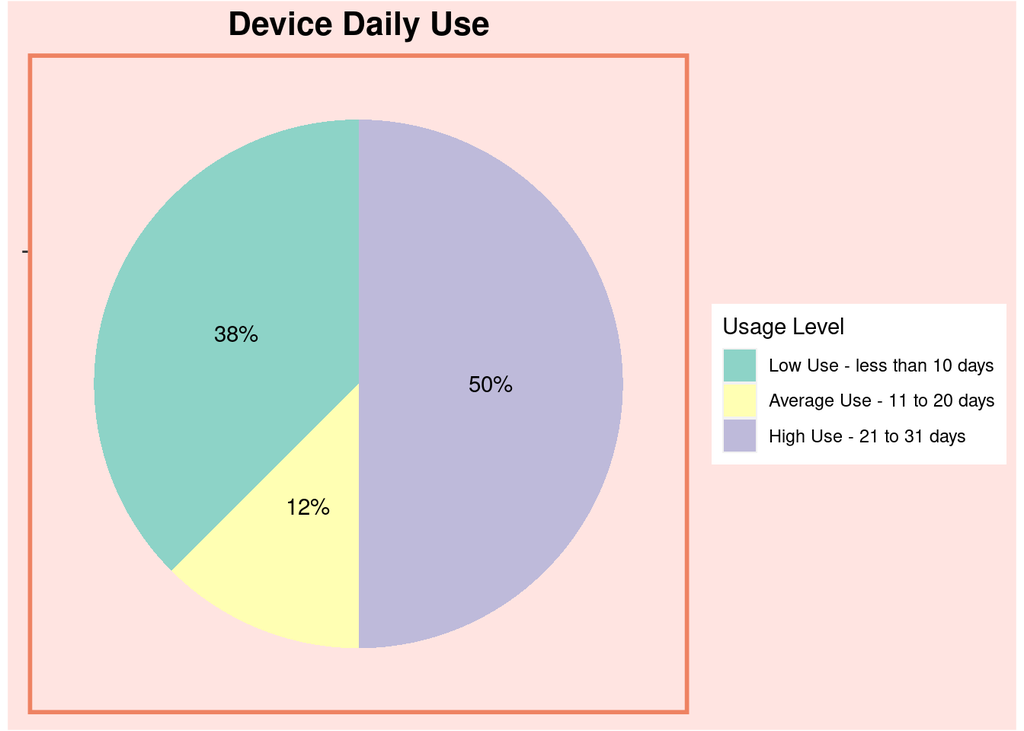

```r
# Calculate percentage of device usage
# Define the usage level for each user
usage_level <- daily_activity_sleep_clean %>%
  group_by(id) %>%
  summarize(n_days_used = sum(n())) %>%
  mutate(level = case_when(n_days_used >= 1 & n_days_used <= 10 ~ "Low Use - less than 10 days",
                           n_days_used >= 11 & n_days_used <= 20 ~ "Average Use - 11 to 20 days",
                           n_days_used >= 21 & n_days_used <= 31 ~ "High Use - 21 to 31 days"
                           ))

usage_pct <- usage_level %>%
  group_by(level) %>%
  summarize(level_count = n()) %>%
  mutate(total_user = sum(level_count)) %>%
  group_by(level) %>%
  summarize(total_pct = level_count / total_user) %>%
  mutate(Label = scales::percent(total_pct))

usage_pct$level <- ordered(usage_pct$level, levels = c("Low Use - less than 10 days",
                                                                   "Average Use - 11 to 20 days",
                                                                   "High Use - 21 to 31 days"))

# Pie Chart of daily usage
usage_pct_pie <- ggplot(usage_pct, aes(x = "", y = total_pct, fill = level)) +
  geom_bar(stat = "identity", width = 1) +
  coord_polar("y", start = 0) +
  theme +
  theme(axis.title.x = element_blank(),
        axis.title.y = element_blank(),
        panel.grid = element_blank(),
        axis.text.x = element_blank(),
        plot.title = element_text(size = 16, face = "bold", hjust = 0.5)) +
  geom_text(aes(label =  Label),
            position = position_stack(vjust = 0.5)) +
  scale_fill_brewer(palette = "Set3") +
  labs(title = "Device Daily Use", fill = "Usage Level")

usage_pct_pie
```

##### What about time of usage per day?

We could assume that the sum of sedentary, light, fair and very active minutes would result in the total time the device was worn. If a user would use it the whole day (24h) these values would amount to 1440min.  
Let’s divide our subjects into categories by total minutes of device usage.

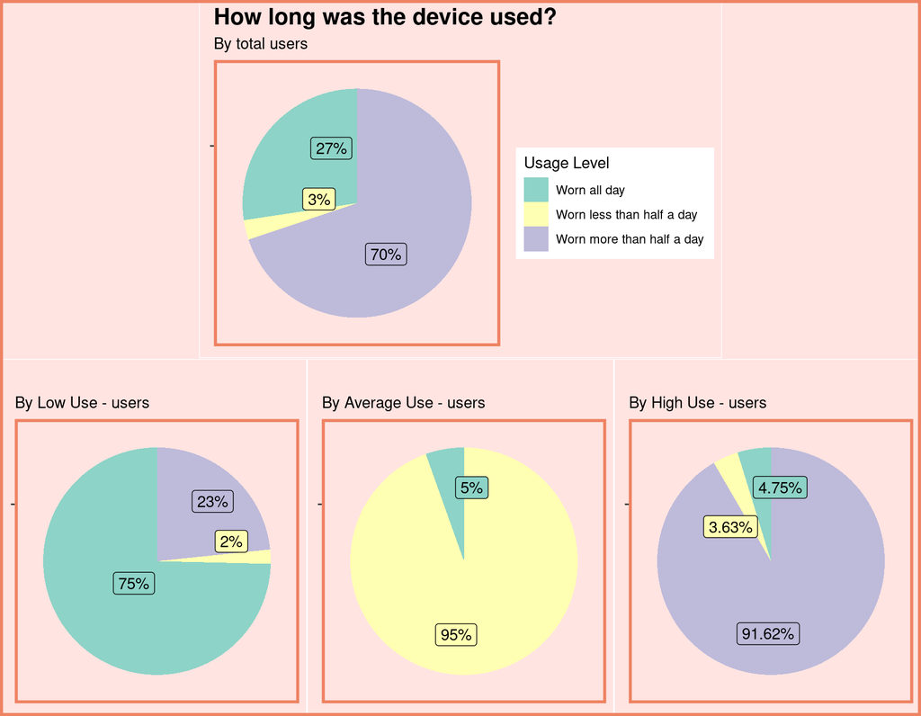

```r
daily_usage_merge <- merge(daily_activity_clean, usage_level, by = c("id"))


minutes_usage <- daily_usage_merge %>%
  mutate(total_minutes_usage =
              sedentary_minutes + lightly_active_minutes + fairly_active_minutes + very_active_minutes) %>%
  mutate(pct_minutes_usage = (total_minutes_usage / 1440) * 100) %>%
  mutate(usage_level = case_when(pct_minutes_usage == 100 ~ "Worn all day",
                                 pct_minutes_usage < 100 & pct_minutes_usage >= 50 ~ "Worn more than half a day",
                                 pct_minutes_usage < 50  & pct_minutes_usage > 0 ~ "Worn less than half a day"))

# Percentage of usage
minutes_usage_pct <- minutes_usage %>%
  group_by(usage_level)%>%
  summarize(count = n()) %>%
  mutate(total = sum(count)) %>%
  group_by(usage_level) %>%
  summarize(pct = count / total) %>%
  mutate(label = scales::percent(pct))

# Percentage of usage, filtered by category
# High use
minutes_worn_high <- minutes_usage %>%
  filter(level == "High Use - 21 to 31 days") %>%
  group_by(usage_level) %>%
  summarize(count = n()) %>%
  mutate(total = sum(count)) %>%
  group_by(usage_level) %>%
  summarize(pct = count / total) %>%
  mutate(label = scales::percent(pct, scale = 100, accuracy = 0.01))

# Average use
minutes_worn_average <- minutes_usage %>%
  filter(level == "Average Use - 11 to 20 days") %>%
  group_by(usage_level) %>%
  summarize(count = n()) %>%
  mutate(total = sum(count)) %>%
  group_by(usage_level) %>%
  summarize(pct = count / total) %>%
  mutate(label = scales::percent(pct))

# Low use
minutes_worn_low <- minutes_usage %>%
  filter(level == "Low Use - less than 10 days") %>%
  group_by(usage_level) %>%
  summarize(count = n()) %>%
  mutate(total = sum(count)) %>%
  group_by(usage_level) %>%
  summarize(pct = count / total) %>%
  mutate(label = scales::percent(pct))


# Plot #1 - usage by group.
total_usage_plot <- ggplot(minutes_usage_pct, aes(x = "", y = pct, fill = usage_level)) +
  geom_bar(stat = "identity",width = 1) +
  coord_polar("y", start = 0) +
  theme +
  theme(axis.title.x = element_blank(),
        axis.title.y = element_blank(),
        panel.grid = element_blank(),
        axis.text.x = element_blank(),
        plot.title = element_text(size = 16, face = "bold")) +
  scale_fill_brewer(palette = "Set3") +
  geom_label_repel(aes(label = label),
                   position = position_stack(vjust = 0.5))+
  guides(fill = guide_legend(override.aes = aes(color = NA))) +
  labs(title = "How long was the device used?", subtitle = "By total users", fill = "Usage Level")

# Plot #2 - Low Usage
low_usage_plot <- ggplot(minutes_worn_low, aes(x = "", y = pct, fill = usage_level)) +
  geom_bar(stat = "identity", width = 1) +
  coord_polar("y", start = 0) +
  theme +
  theme(axis.title.x = element_blank(),
        axis.title.y = element_blank(),
        panel.grid = element_blank(),
        axis.text.x = element_blank(),
        legend.position = "none",
        plot.title = element_text(size = 16, face = "bold")) +
  scale_fill_brewer(palette = "Set3") +
  geom_label_repel(aes(label = label),
                   position = position_stack(vjust = 0.5))+
  guides(fill = guide_legend(override.aes = aes(color = NA))) +
  labs(title = "", subtitle = "By Low Use - users", fill = "Usage Level")

# Plot #3 - Average Usage
average_usage_plot <- ggplot(minutes_worn_average, aes(x = "", y = pct, fill = usage_level)) +
  geom_bar(stat = "identity", width = 1) +
  coord_polar("y", start = 0) +
  theme +
  theme(axis.title.x = element_blank(),
        axis.title.y = element_blank(),
        panel.grid = element_blank(),
        axis.text.x = element_blank(),
        legend.position = "none",
        plot.title = element_text(size = 16, face = "bold")) +
  scale_fill_brewer(palette = "Set3") +
  geom_label_repel(aes(label = label),
                   position = position_stack(vjust = 0.5)) +
  guides(fill = guide_legend(override.aes = aes(color = NA))) +
  labs(title = "", subtitle = "By Average Use - users ", fill = "Usage Level")

# Plot #4 - High Usage
high_usage_plot <- ggplot(minutes_worn_high, aes(x = "", y = pct, fill = usage_level)) +
  geom_bar(stat = "identity", width = 1) +
  coord_polar("y", start = 0) +
  theme +
  theme(axis.title.x = element_blank(),
        axis.title.y = element_blank(),
        panel.grid = element_blank(),
        axis.text.x = element_blank(),
        legend.position = "none",
        plot.title = element_text(size = 16, face = "bold")) +
  scale_fill_brewer(palette = "Set3") +
  geom_label_repel(aes(label = label),
                   position = position_stack(vjust=0.5)) +
  guides(fill = guide_legend(override.aes = aes(color = NA))) +
  labs(title = "", subtitle = "By High Use - users", fill = "Usage Level")

groups_usage_plot <- ggarrange(low_usage_plot, average_usage_plot, high_usage_plot, ncol = 3)
final_usage_plot <- ggarrange(total_usage_plot, groups_usage_plot, nrow = 2, common.legend = FALSE) +
  theme

final_usage_plot
```

## **6. Act**

### Before I present my final recomendations, I’d like to explain some characteristics of this sample.

This data was collected in 2016 and brings little relevancy for this study in 2023. Demographic information is also missing and we can’t be sure if this sample is relevant, as Bellabeat focus is on health products for women.  
We may be risking sampling bias.  
Nevertheless, let’s finish the analysis.

### Final Recommendations

Considering the previous takeaways, after this analysis the marketing analytics team can develop an action plan to implement features into our Bellabeat products. Focusing on the *Bellabeat App* and the *Leaf* tracker, my recommendations are:

1. **Alarm clock on Leaf tracker** to remind user when it’s almost time for their daily activity;
2. **App feature that allows users to choose their desired time to wake up**. This will calculate the ideal sleep duration (between 7 to 8 hours) and the exact time to go to bed. Users will then receive a reminder on their **Leaf**, 5 to 10 minutes before the calculated hour. Users can also choose a regular hour to go to sleep and will receive the same notification to prepare to rest.
3. **App notifications sharing studies and the benefits of reaching the steps milestones**. This may encourage our Bellabeat users to “go the extra mile” if they aren’t reaching their goals.
4. Seeing that 75% of **Low Use users** had worn their device the whole day, if future Beallabeat user behave the same way, we should engage with them so they can be more active. My suggestion would be a **game within the app, where users would win currency by reaching fitness milestones**. These would include trivia health questions, number of steps, higher intensity would return higher currency. Users could even have their own avatar and customize it by redeeming their currency! **This could help develop some sort of social network** and even promote group exercises, like walks in the park or going for a run around the block. Do you need a gym buddy to keep you in check?
5. **Average Use users** seem to be a good source of feedback. We could run **surveys to understand why they don’t use their devices more often. What characteristics are they looking for in fitness trackers?**. Also, creating an **in-game streak feature that challenges the user to keep an above average activity level** could help keep these users more interested;
6. And since **High Use users** tend to wear their device for more than half a day, why would they take it off? **Do they know our Bellabeat Leaf tracker can be worn as a bracelet, neckalce or clip?** Here’s an opportunity to (**humbly**) brag about our fashionable and elegant products, a perfect match to any occasion, through newsletters and marketing campaign whenever new releases are coming up;
7. On Sundays, users will usually rest, but that doesn’t mean they can’t keep their fitness goals in check. **“How was my week?” report**! Users will receive an end of the week **report with their most noticeable accolades and milestones, rewards, and a preview of their next week’s goals**.

## Final thoughts

### **Thank you for following my first R project!**

It was indeed a fabulous learning adventure and I’m sure to keep on developing my skills and present better analysis.

Any doubts or suggestions, please let me know. I’d appreciate any feedback!  
Once again, thank you for your time.